# MY580 Lab 2: Difference-in-Differences

Author

Zach Dickson

# 1 Overview

On **1 April 1992**, New Jersey raised its minimum wage from $4.25 to **$5.05** an hour, one of the highest in the US at the time. Next door, Pennsylvania stayed at the federal minimum of $4.25. The textbook competitive model predicts that a higher minimum wage **reduces employment**: if labour costs more, firms hire less. Did it?

We can’t randomly assign minimum wages to states, so Card & Krueger (1994) used a **difference-in-differences (DiD)** design. They surveyed 410 fast-food restaurants (Burger King, KFC, Roy Rogers and Wendy’s) in New Jersey and eastern Pennsylvania **before** the increase (February–March 1992) and **after** it (November–December 1992). We compare the *change* in employment in New Jersey restaurants with the *change* in Pennsylvania restaurants over the same period.

We will:

0. *(Warm-up)* Draw the DAG for this design
1. Load the data and build the treatment and post-period indicators
2. Check that the treatment actually happened: did wages rise?
3. Estimate a 2×2 DiD by hand, with regression and with two-way fixed effects
4. Use variation **within** New Jersey as a second comparison
5. *(Simulation)* See what an event study adds when we have more time periods

Look for the **✏️ Your turn** prompts.

# 2 Setup

```r
# install packages if they are not already installed
packages_to_install <- c("fixest", "tidyverse", "dagitty", "ggdag")

for (package_name in packages_to_install) {
  if (!(package_name %in% installed.packages())) {
    install.packages(package_name)
  }
}

library(fixest)    # for fixed effects regression
library(tidyverse) # for data manipulation
library(dagitty)   # for specifying DAGs
library(ggdag)     # for plotting DAGs
```

# 3 Warm-up (optional): The DAG

Before touching data, let’s write down our assumptions. New Jersey and Pennsylvania might differ in ways that also affect fast-food employment: for example, local labour markets, population or consumer demand. Employment also changes over time for everyone, e.g. with the seasons or the 1990–92 recession. And *when* the new minimum applies is itself a feature of time: treatment only switches on after April 1992.

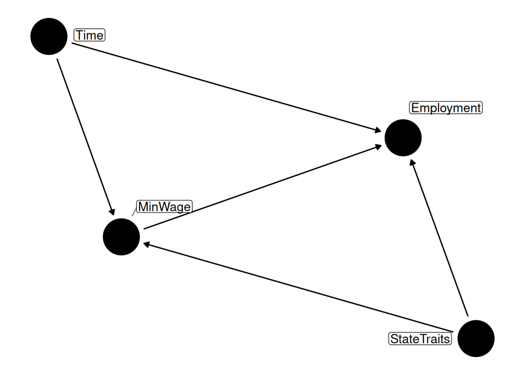

```r
dag <- dagitty('dag {
  MinWage -> Employment
  StateTraits -> MinWage
  StateTraits -> Employment
  Time -> MinWage
  Time -> Employment
}')

ggdag(dag, text = FALSE, use_labels = "name") + theme_dag()
```

There are two back-door paths: `MinWage <- StateTraits -> Employment` and `MinWage <- Time -> Employment`. `dagitty` can tell us what we need to adjust for to close them:

```r
adjustmentSets(dag, exposure = "MinWage", outcome = "Employment")
```

```
{ StateTraits, Time }
```

We can’t measure every state trait. DiD gets around this by comparing each restaurant **with itself** over time: anything about a restaurant that is fixed across our two survey waves cancels out (restaurant fixed effects close the first path). Comparing with Pennsylvania restaurants over the same months removes common shocks over time (wave fixed effects close the second). What DiD *can’t* handle is something that changes differently over time in New Jersey and Pennsylvania. That is the **parallel trends** assumption.

# 4 Load the data

The data are the original survey data from [David Card’s website](https://davidcard.berkeley.edu/data_sets.html), reshaped so that each row is a **restaurant in a survey wave**. They can be read directly from GitHub, or from your local copy if you’ve cloned the repository.

```r
# load data from GitHub
# data <- read_csv("https://raw.githubusercontent.com/z-dickson/my580-causal-inference/main/data/card_krueger_minwage.csv")

# or, load data from local file if you've cloned the repository
data <- read_csv("../data/card_krueger_minwage.csv")

head(data)
```

```
# A tibble: 6 × 13
  store_id state       region chain co_owned  wave status emp_ft emp_pt managers
     <dbl> <chr>       <chr>  <chr>    <dbl> <dbl> <chr>   <dbl>  <dbl>    <dbl>
1        1 Pennsylvan… PA: P… Burg…        0     1 open     30     15          3
2        1 Pennsylvan… PA: P… Burg…        0     2 open      3.5   35          3
3        2 Pennsylvan… PA: P… KFC          0     1 open      6.5    6.5        4
4        2 Pennsylvan… PA: P… KFC          0     2 open      0     15          4
5        3 Pennsylvan… PA: P… KFC          1     1 open      3      7          2
6        3 Pennsylvan… PA: P… KFC          1     2 open      3      7          4
# ℹ 3 more variables: starting_wage <dbl>, hours_open <dbl>, price_meal <dbl>
```

We have 410 restaurants observed in 2 waves (`wave = 1` before the increase, `wave = 2` after). The main variables are:

| Variable | Description |
| --- | --- |
| `state`, `region` | New Jersey or Pennsylvania, and the area within each state |
| `chain`, `co_owned` | Restaurant chain, and whether it is owned by the company (vs. a franchisee) |
| `status` | In wave 2: open, closed (permanently or temporarily), or refused the interview |
| `emp_ft`, `emp_pt`, `managers` | Number of full-time workers, part-time workers and managers |
| `starting_wage` | Starting hourly wage ($) |
| `price_meal`, `hours_open` | Price of a soda, fries and main dish ($); hours open per day |

```r
data %>% filter(wave == 1) %>% count(state, region)
```

```
# A tibble: 5 × 3
  state        region                       n
  <chr>        <chr>                    <int>
1 New Jersey   Central NJ                  63
2 New Jersey   North NJ                   175
3 New Jersey   South NJ                    93
4 Pennsylvania PA: Easton area             43
5 Pennsylvania PA: Philadelphia suburbs    36
```

# 5 Data preparation

## 5.1 Outcome: full-time equivalent employment

Following Card & Krueger, our outcome is **full-time equivalent (FTE) employment**: full-time workers plus managers, plus part-time workers counted as half a worker each.

**A note on data quality**

Employment was reported by restaurant managers over the phone, so it is measured with error. Six restaurants **closed permanently** between the waves. They are recorded with zero employees, so their lost jobs count in the analysis. Restaurants that were **temporarily closed** (renovations, a road closure and a mall fire) have missing values. Try the DiD without the closed restaurants and see whether the conclusion changes.

```r
data <- data %>%
  mutate(fte = emp_ft + 0.5 * emp_pt + managers)

data %>% count(wave, status)
```

```
# A tibble: 5 × 3
   wave status                 n
  <dbl> <chr>              <int>
1     1 open                 410
2     2 closed permanently     6
3     2 closed temporarily     4
4     2 open                 399
5     2 refused                1
```

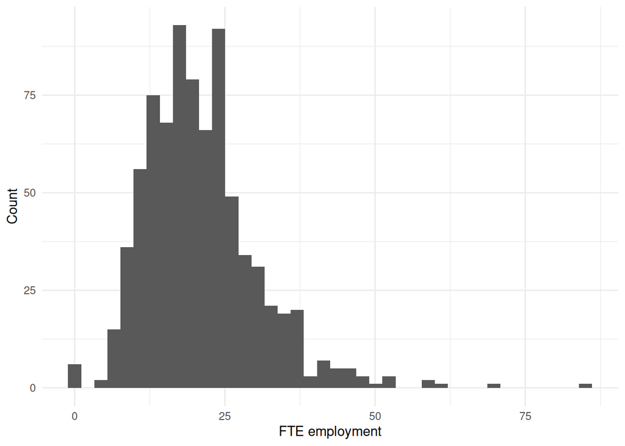

```r
ggplot(data, aes(x = fte)) +
  geom_histogram(bins = 40) +
  labs(x = "FTE employment", y = "Count") +
  theme_minimal()
```

## 5.2 Treatment and post-period indicators

The **treatment group** is the restaurants in New Jersey. The **control group** is the restaurants in Pennsylvania.

```r
data <- data %>%
  mutate(nj = ifelse(state == "New Jersey", 1, 0))

# check the treatment variable
data %>% count(state, nj)
```

```
# A tibble: 2 × 3
  state           nj     n
  <chr>        <dbl> <int>
1 New Jersey       1   662
2 Pennsylvania     0   158
```

The new minimum wage took effect between the two waves, so the **post** period is wave 2.

```r
data <- data %>%
  mutate(post = ifelse(wave == 2, 1, 0))
```

The DiD treatment indicator is 1 only for **New Jersey restaurants in the post period**:

```r
data <- data %>%
  mutate(under_treatment = nj * post)

data %>% count(state, wave, under_treatment)
```

```
# A tibble: 4 × 4
  state         wave under_treatment     n
  <chr>        <dbl>           <dbl> <int>
1 New Jersey       1               0   331
2 New Jersey       2               1   331
3 Pennsylvania     1               0    79
4 Pennsylvania     2               0    79
```

# 6 Did the treatment happen?

Before estimating the effect *of* the minimum wage, check that the law actually changed what restaurants paid. If New Jersey wages hadn’t moved, there would be nothing to estimate. The plot below shows the distribution of starting wages in each state, before and after.

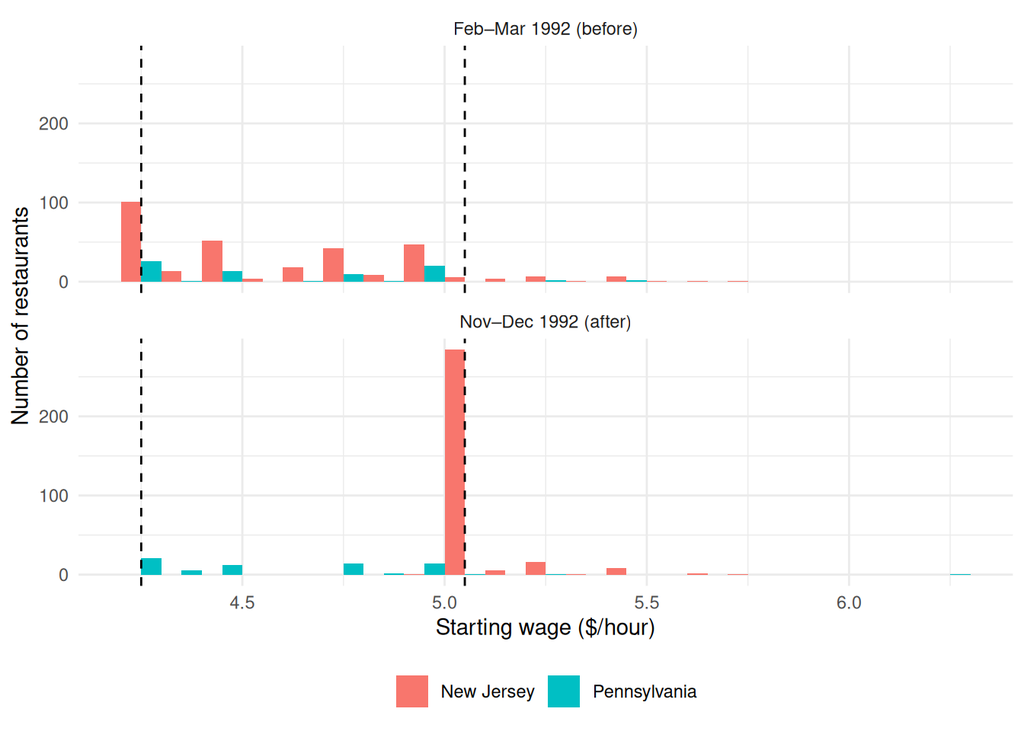

```r
data %>%
  mutate(wave = ifelse(wave == 1, "Feb–Mar 1992 (before)", "Nov–Dec 1992 (after)")) %>%
  ggplot(aes(x = starting_wage, fill = state)) +
  geom_histogram(binwidth = 0.1, position = "dodge", boundary = 4.2) +
  geom_vline(xintercept = c(4.25, 5.05), linetype = "dashed") +
  facet_wrap(~ wave, ncol = 1) +
  labs(x = "Starting wage ($/hour)", y = "Number of restaurants", fill = NULL) +
  theme_minimal() +
  theme(legend.position = "bottom")
```

**✏️ Your turn**

1. Describe what happened to starting wages in New Jersey. What happened in Pennsylvania?
2. Estimate a DiD with `starting_wage` as the outcome (copy the regression in the next section and change the outcome). How much did the law raise wages?
3. Before the increase, some New Jersey restaurants already paid more than $5.05. Should the law have affected them? We’ll come back to this.

# 7 The 2×2 difference-in-differences

## 7.1 Visualizing the comparison

With only two time periods, the whole design fits in one plot. The dashed line is the **counterfactual**: where New Jersey would have ended up if it had followed Pennsylvania’s trend.

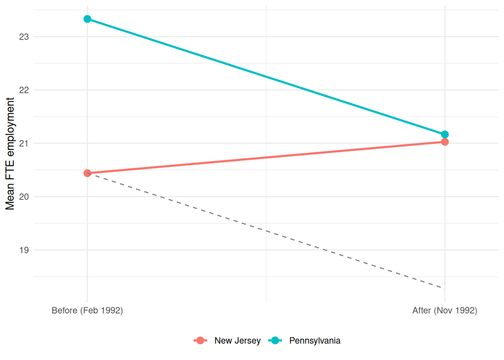

```r
means <- data %>%
  group_by(state, nj, post) %>%
  summarise(fte = mean(fte, na.rm = TRUE))

nj_counterfactual <- tibble(
  post = c(0, 1),
  fte = c(means$fte[means$nj == 1 & means$post == 0],
          means$fte[means$nj == 1 & means$post == 0] +
            means$fte[means$nj == 0 & means$post == 1] - means$fte[means$nj == 0 & means$post == 0]))

ggplot(means, aes(x = post, y = fte, colour = state)) +
  geom_line(linewidth = 1) +
  geom_point(size = 3) +
  geom_line(data = nj_counterfactual, aes(x = post, y = fte), inherit.aes = FALSE,
            linetype = "dashed", colour = "grey50") +
  scale_x_continuous(breaks = c(0, 1), labels = c("Before (Feb 1992)", "After (Nov 1992)"),
                     expand = expansion(mult = 0.15)) +
  labs(x = NULL, y = "Mean FTE employment", colour = NULL) +
  theme_minimal() +
  theme(legend.position = "bottom")
```

**✏️ Your turn**

In Lab 1 and in the lecture we checked parallel trends by looking at the **pre-treatment** period. Can we do that here? What would we need?

## 7.2 By hand

The simplest DiD uses four averages:

```r
means
```

```
# A tibble: 4 × 4
# Groups:   state, nj [2]
  state           nj  post   fte
  <chr>        <dbl> <dbl> <dbl>
1 New Jersey       1     0  20.4
2 New Jersey       1     1  21.0
3 Pennsylvania     0     0  23.3
4 Pennsylvania     0     1  21.2
```

```r
treated_change <- means$fte[means$nj == 1 & means$post == 1] -
                  means$fte[means$nj == 1 & means$post == 0]
control_change <- means$fte[means$nj == 0 & means$post == 1] -
                  means$fte[means$nj == 0 & means$post == 0]

c(treated_change = treated_change, control_change = control_change,
  did = treated_change - control_change)
```

```
treated_change control_change            did
     0.5880214     -2.1655844      2.7536058
```

The control group’s change is our estimate of what *would have happened* to New Jersey without the new minimum wage. The DiD is New Jersey’s change **minus** that counterfactual change.

## 7.3 With regression

The same estimate comes from a regression with an interaction:

$$Y_{it} = \beta_0 + \beta_1 \text{NJ}_i + \beta_2 \text{post}_t + \delta (\text{NJ}_i \times \text{post}_t) + \varepsilon_{it}$$

- $\beta_1$: the pre-period difference between New Jersey and Pennsylvania restaurants
- $\beta_2$: the change over time in Pennsylvania restaurants
- $\delta$: the **difference in differences**, our estimate of the ATT

```r
did_simple <- feols(fte ~ nj * post, data = data, vcov = ~ store_id)
```

```
NOTE: 26 observations removed because of NA values (LHS: 26).
```

```r
etable(did_simple)
```

```
                      did_simple
Dependent Var.:              fte

Constant        23.33*** (1.347)
nj               -2.892* (1.440)
post             -2.166. (1.218)
nj x post         2.754* (1.307)
_______________ ________________
S.E.: Clustered     by: store_id
Observations                 794
R2                       0.00740
Adj. R2                  0.00363
---
Signif. codes: 0 '***' 0.001 '**' 0.01 '*' 0.05 '.' 0.1 ' ' 1
```

The coefficient on `nj x post` matches our hand calculation. We cluster standard errors by **restaurant**, because each restaurant appears twice.

## 7.4 With two-way fixed effects

In practice, DiD is usually estimated with **restaurant fixed effects** ($\alpha_i$) and **wave fixed effects** ($\lambda_t$):

$$Y_{it} = \alpha_i + \lambda_t + \delta \, D_{it} + \varepsilon_{it}$$

where $D_{it} = \text{NJ}_i \times \text{post}_t$ (our `under_treatment` variable).

- $\alpha_i$ absorbs everything fixed about a restaurant (it replaces $\beta_1$)
- $\lambda_t$ absorbs everything that affects all restaurants in a given wave (it replaces $\beta_2$)

In `fixest`, fixed effects go after the `|`.

```r
did_twfe <- feols(fte ~ under_treatment | store_id + wave, data = data, vcov = ~ store_id)
```

```
NOTES: 26 observations removed because of NA values (LHS: 26).
       26/0 fixed-effect singletons were removed (26 observations).
```

```r
etable(did_simple, did_twfe)
```

```
                      did_simple       did_twfe
Dependent Var.:              fte            fte

Constant        23.33*** (1.347)
nj               -2.892* (1.440)
post             -2.166. (1.218)
nj x post         2.754* (1.307)
under_treatment                  2.750* (1.338)
Fixed-Effects:  ---------------- --------------
store_id                      No            Yes
wave                          No            Yes
_______________ ________________ ______________
S.E.: Clustered     by: store_id   by: store_id
Observations                 794            768
R2                       0.00740        0.77944
Within R2                     --        0.01464
---
Signif. codes: 0 '***' 0.001 '**' 0.01 '*' 0.05 '.' 0.1 ' ' 1
```

The estimate barely moves, but notice the number of observations. Restaurant fixed effects can only use restaurants observed in **both** waves, so the TWFE model compares each restaurant with itself.

## 7.5 Adding controls

Card & Krueger also controlled for the restaurant’s chain and ownership. With two periods, TWFE is the same as regressing each restaurant’s **change** in employment on treatment. That makes it easy to add controls, which then adjust for **different trends** by chain or ownership.

```r
changes <- data %>%
  select(store_id, state, region, chain, co_owned, nj, wave, fte, starting_wage) %>%
  pivot_wider(names_from = wave, values_from = c(fte, starting_wage)) %>%
  mutate(change_fte = fte_2 - fte_1)

did_fd <- feols(change_fte ~ nj, data = changes, vcov = "hetero")
```

```
NOTE: 26 observations removed because of NA values (LHS: 26).
```

```r
did_fd_controls <- feols(change_fte ~ nj + chain + co_owned, data = changes, vcov = "hetero")
```

```
NOTE: 26 observations removed because of NA values (LHS: 26).
```

```r
etable(did_twfe, did_fd, did_fd_controls)
```

```
                      did_twfe          did_fd did_fd_controls
Dependent Var.:            fte      change_fte      change_fte

under_treatment 2.750* (1.338)
Constant                       -2.283. (1.248)  -1.828 (1.539)
nj                              2.750* (1.338)  2.785* (1.341)
chainKFC                                        0.2408 (1.047)
chainRoy Rogers                                -2.588* (1.141)
chainWendy's                                   -0.1910 (1.705)
co_owned                                       0.3625 (0.8946)
Fixed-Effects:  -------------- --------------- ---------------
store_id                   Yes              No              No
wave                       Yes              No              No
_______________ ______________ _______________ _______________
S.E. type         by: store_id Heteroske.-rob. Heteroske.-rob.
Observations               768             384             384
R2                     0.77944         0.01464         0.02904
Within R2              0.01464              --              --
---
Signif. codes: 0 '***' 0.001 '**' 0.01 '*' 0.05 '.' 0.1 ' ' 1
```

**✏️ Your turn**

1. Write one sentence interpreting the TWFE estimate for a non-technical audience.
2. Is the sign what the textbook model predicts?
3. Re-run the TWFE model without the restaurants that closed (`filter(!str_detect(status, "closed"))`) or without the restaurants that changed the number of hours they were open. Does the conclusion change?
4. Try `price_meal` as the outcome. If employers didn’t cut jobs, how else might they have paid for higher wages?

# 8 Inference: how many treated units do we really have?

We have about 400 restaurants, but the minimum wage was set for only **one** treated state, and compared with only **one** control state. Anything else that happened to New Jersey but not Pennsylvania in 1992 (a state budget, a local boom, a bad winter) is perfectly mixed up with the treatment. Restaurants in the same state share these shocks, so they aren’t independent pieces of evidence.

In the lecture the advice was to **cluster at the level at which treatment is assigned**. Here that would be the state, and with two clusters there is no reliable way to do it. Our standard errors assume that the only shocks are restaurant-specific. That is an assumption, not a fact.

One answer is to find **another comparison that doesn’t rely on Pennsylvania**.

# 9 A second comparison within New Jersey

Not every New Jersey restaurant was equally affected. A restaurant already paying $5.05 or more didn’t have to change anything, while one paying $4.25 had to raise wages by 19%. If something *else* happened to New Jersey in 1992, it should affect high-wage and low-wage New Jersey restaurants alike. If the minimum wage drives the result, only the low-wage restaurants should change.

```r
nj_changes <- changes %>%
  filter(nj == 1, !is.na(starting_wage_1)) %>%
  mutate(wage_group = case_when(
    starting_wage_1 == 4.25 ~ "Low ($4.25)",
    starting_wage_1 >= 5.00 ~ "High ($5.00+)",
    TRUE ~ "Middle"))

nj_changes %>%
  group_by(wage_group) %>%
  summarise(n = n(),
            wage_before = mean(starting_wage_1, na.rm = TRUE),
            wage_after = mean(starting_wage_2, na.rm = TRUE),
            change_fte = mean(change_fte, na.rm = TRUE))
```

```
# A tibble: 3 × 5
  wage_group        n wage_before wage_after change_fte
  <chr>         <int>       <dbl>      <dbl>      <dbl>
1 High ($5.00+)    73        5.11       5.11     -2.16
2 Low ($4.25)     101        4.25       5.06      1.20
3 Middle          140        4.61       5.08      0.710
```

Compare the low-wage group with the high-wage group: another DiD, with high-wage New Jersey restaurants as the control group.

```r
did_within_nj <- feols(change_fte ~ i(wage_group, ref = "High ($5.00+)"),
                       data = filter(nj_changes, wage_group != "Middle"), vcov = "hetero")
```

```
NOTE: 13 observations removed because of NA values (LHS: 13).
```

```r
etable(did_within_nj)
```

```
                           did_within_nj
Dependent Var.:               change_fte

Constant                 -2.157* (1.006)
wage_group = Low ($4.25)  3.362* (1.300)
________________________ _______________
S.E. type                Heteroske.-rob.
Observations                         161
R2                               0.04077
Adj. R2                          0.03473
---
Signif. codes: 0 '***' 0.001 '**' 0.01 '*' 0.05 '.' 0.1 ' ' 1
```

Card & Krueger went one step further. They measured each restaurant’s **wage gap**: the percentage increase needed to reach the new $5.05 minimum (zero for Pennsylvania and for high-wage New Jersey restaurants). If the minimum wage reduces employment, restaurants with a bigger gap should lose more jobs.

```r
changes <- changes %>%
  mutate(wage_gap = case_when(
    nj == 0 ~ 0,
    starting_wage_1 >= 5.05 ~ 0,
    TRUE ~ (5.05 - starting_wage_1) / starting_wage_1))

did_gap <- feols(change_fte ~ wage_gap + chain + co_owned, data = changes, vcov = "hetero")
```

```
NOTE: 42 observations removed because of NA values (LHS: 26, RHS: 17).
```

```r
etable(did_gap)
```

```
                        did_gap
Dependent Var.:      change_fte

Constant         -1.542 (1.184)
wage_gap         15.88* (6.320)
chainKFC         0.8080 (1.091)
chainRoy Rogers  -1.843 (1.180)
chainWendy's     0.3551 (1.618)
co_owned        0.4308 (0.9073)
_______________ _______________
S.E. type       Heteroske.-rob.
Observations                368
R2                      0.03167
Adj. R2                 0.01830
---
Signif. codes: 0 '***' 0.001 '**' 0.01 '*' 0.05 '.' 0.1 ' ' 1
```

**✏️ Your turn**

1. How did employment change in high-wage New Jersey restaurants? How does that compare with Pennsylvania?
2. What does this suggest about the worry that something other than the minimum wage happened in New Jersey?
3. The `wage_gap` coefficient is the effect of a 100% wage increase. What would a 10% increase imply?
4. **Placebo test:** compare the two Pennsylvania regions (`region`), neither of which was treated. What *should* you find? What do you find?

**So what do we conclude?**

In these data, employment in New Jersey **rose slightly** relative to Pennsylvania, the opposite of the textbook prediction. The result holds when we compare low- and high-wage restaurants *within* New Jersey, which makes a New Jersey-wide shock a less likely explanation. But we only have one treated state, two time periods and noisy phone surveys, so we can’t check pre-trends and our standard errors may be too small. The paper started a long debate: Neumark & Wascher (2000) found employment losses using payroll records, and Card & Krueger (2000) found no losses using government employment data.

# 10 Simulation: what an event study adds

With only two periods, the parallel trends assumption is **untestable**: we have no pre-treatment trend to look at. Suppose New Jersey’s fast-food employment was already growing faster than Pennsylvania’s before 1992. A 2×2 DiD would wrongly attribute that growth to the minimum wage.

We can’t check this in Card & Krueger’s data, so let’s **simulate** a world where we observe restaurants for 8 quarters, with the minimum wage introduced in quarter 5. The true effect of the minimum wage is **zero**. In one world trends are parallel; in the other, New Jersey is on a steeper upward trend.

```r
set.seed(580)

simulate_panel <- function(nj_extra_trend) {
  expand_grid(store_id = 1:400, quarter = 1:8) %>%
    group_by(store_id) %>%
    mutate(store_effect = rnorm(1, mean = 0, sd = 5)) %>%   # fixed restaurant traits
    ungroup() %>%
    mutate(nj = as.numeric(store_id <= 300),
           post = as.numeric(quarter >= 5),
           under_treatment = nj * post,
           fte = 20 + store_effect - 3 * nj                  # NJ starts lower
                 - 0.4 * quarter                             # common trend
                 + nj_extra_trend * nj * quarter             # NJ-specific trend
                 + 0 * under_treatment                       # true effect = 0
                 + rnorm(n(), mean = 0, sd = 2))
}

parallel <- simulate_panel(nj_extra_trend = 0)
diverging <- simulate_panel(nj_extra_trend = 1.5)
```

A 2×2 DiD using only the quarter before and the quarter after the policy (like Card & Krueger’s two waves):

```r
etable(feols(fte ~ nj * post, data = filter(parallel, quarter %in% 4:5), vcov = ~ store_id),
       feols(fte ~ nj * post, data = filter(diverging, quarter %in% 4:5), vcov = ~ store_id),
       headers = c("Parallel trends", "Diverging trends"))
```

```
                feols(fte ~ nj *.. feols(fte ~ nj *...1
                   Parallel trends     Diverging trends
Dependent Var.:                fte                  fte

Constant         18.39*** (0.5646)    19.11*** (0.5927)
nj              -2.817*** (0.6347)    2.435*** (0.6634)
post            -0.8885** (0.2794)   -0.7363** (0.2511)
nj x post          0.5215 (0.3238)    1.821*** (0.2987)
_______________ __________________   __________________
S.E.: Clustered       by: store_id         by: store_id
Observations                   800                  800
R2                         0.04605              0.07622
Adj. R2                    0.04245              0.07273
---
Signif. codes: 0 '***' 0.001 '**' 0.01 '*' 0.05 '.' 0.1 ' ' 1
```

An **event study** estimates a separate effect for each quarter relative to a reference quarter. We use the last pre-treatment quarter (quarter 4) as the reference, so every coefficient is relative to the quarter before the policy.

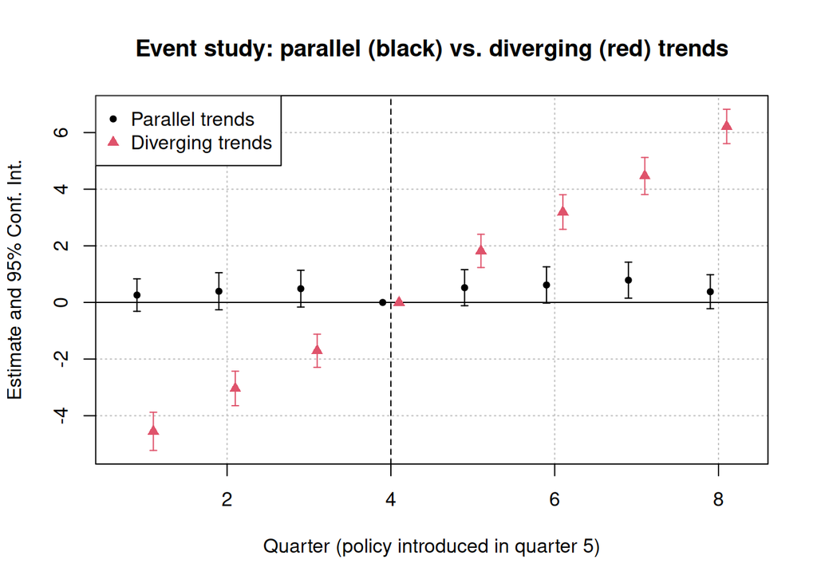

```r
es_parallel <- feols(fte ~ i(quarter, nj, ref = 4) | store_id + quarter,
                     data = parallel, vcov = ~ store_id)
es_diverging <- feols(fte ~ i(quarter, nj, ref = 4) | store_id + quarter,
                      data = diverging, vcov = ~ store_id)

iplot(list(es_parallel, es_diverging),
      xlab = "Quarter (policy introduced in quarter 5)",
      main = "Event study: parallel (black) vs. diverging (red) trends")
legend("topleft", col = c(1, 2), pch = c(20, 17), legend = c("Parallel trends", "Diverging trends"))
```

**✏️ Your turn**

1. In the diverging world, the true effect is zero. What does the 2×2 DiD find? Could you have known it was wrong from two periods of data?
2. How do the pre-treatment coefficients (quarters 1–3) differ between the two worlds?
3. Change `nj_extra_trend` to a **negative** number. Which way is the 2×2 estimate biased now?
4. Change the true effect from `0` to `2`. Can the event study still recover it in the parallel world?

# 11 How can we improve the analysis?

- **More time periods:** with several pre-treatment periods we can run an event study and check pre-trends, as in the simulation. Card & Krueger (2000) revisited the question with longer government employment series.
- **More treated and control units:** Dube, Lester & Reich (2010) compare every pair of neighbouring counties on opposite sides of a state border, across many minimum wage increases. This makes inference more credible than one treated state against one control.
- **Placebo and robustness tests:** untreated outcomes, untreated groups (high-wage restaurants), alternative definitions of employment.
- **Staggered timing:** when states raise minimum wages at different times, standard TWFE can be biased. Newer estimators (Callaway & Sant’Anna 2021; Sun & Abraham 2021) fix this. `fixest` implements Sun & Abraham via `sunab()`.

# 12 References

- Card, D., & Krueger, A. B. (1994). Minimum wages and employment: A case study of the fast-food industry in New Jersey and Pennsylvania. *American Economic Review*, 84(4), 772–793.
- Card, D., & Krueger, A. B. (2000). Minimum wages and employment: A case study of the fast-food industry in New Jersey and Pennsylvania: Reply. *American Economic Review*, 90(5), 1397–1420.
- Dube, A., Lester, T. W., & Reich, M. (2010). Minimum wage effects across state borders: Estimates using contiguous counties. *Review of Economics and Statistics*, 92(4), 945–964.
- Neumark, D., & Wascher, W. (2000). Minimum wages and employment: A case study of the fast-food industry in New Jersey and Pennsylvania: Comment. *American Economic Review*, 90(5), 1362–1396.